# Taipei Housing Price Analysis

A Exploratory and Regression Analysis

Cheng Peng West Chester University

June 04, 2026

Abstract

This report presents a comprehensive analysis of housing prices in Taipei, Taiwan, utilizing the structured Visualization Framework (Data Knowledge → Audience Needs → Statistical Analysis → Visual Design → Implementation). The study employs systematic exploratory data analysis, spatial mapping techniques, and multiple regression modeling to identify key factors influencing residential property values.

# 1 Introduction

The Taipei metropolitan area represents one of Asia’s most dynamic real estate markets, characterized by limited land availability, high population density, and rapid urbanization. Understanding the factors that influence housing prices is crucial for multiple stakeholders:

- Homebuyers and investors seeking to make informed purchasing decisions
- Real estate professionals requiring accurate valuation models
- Urban planners and policymakers developing housing policies
- Financial institutions assessing mortgage risk and property collateral

**Objectives**

This project aims to achieve the following objectives:

- Identify the key factors that significantly influence housing prices in Taipei
- Quantify the magnitude and direction of each factor’s effect on property values
- Visualize spatial patterns and relationships within the housing market
- Develop a predictive model for housing price estimation
- Demonstrate the application of the Visualization Framework in real estate analytics

**The Visualization Framework**

This analysis follows a structured five-step framework for effective data visualization and analysis:

| Step | Component Description |
| --- | --- |
| Step 1 | Know the Data Understand structure, types, completeness, and quality |
| Step 2 | Know the Audience Identify stakeholder needs and required insights |
| Step 3 | Apply Analysis Conduct appropriate statistical and exploratory analyses |
| Step 4 | Visual Design Implement effective visualization principles |
| Step 5 | Choose Tools Select appropriate tools for static and interactive output |

**Report Structure**

The remainder of this report is organized as follows:

Section 2: Data acquisition and initial processing

Section 3: Exploratory data analysis and visualization

Section 4: Feature Engineering

Section 5: Regression modeling and diagnostics

Section 6: Results interpretation and discussion

Section 7: Conclusions and recommendations

# 2 Data Acquisition and Processing

This dataset contains information on real estate transactions in a specific area, including details such as the age of the house, proximity to public transportation, and number of nearby convenience stores. The target variable is the price per unit area, measured in thousands of dollars.

[output not shown]

This dataset can be used for various data science projects, including building predictive models to estimate real estate prices based on different influencing factors. The data is clean and ready for analysis, with no missing values.

- **Variable Dictionary**

[output not shown]

- **Initial Data Processing**

The initial data processing includes detection of missing values and suggested remedies as well as data type conversions for subsequent analysis.

```r
# ----  Download Dataset ----
housing_raw <- read.csv("https://pengdsci.github.io/datasets/Realestate.csv")
missing_summary <- summary(housing_raw)
print(missing_summary)
```

```
     ObsID     TransactionYear    HouseAge      Distance2MRT    NumConvenStores    Latitude
 Min.   :  1   Min.   :2012    Min.   : 0.00   Min.   :  23.4   Min.   : 0.00   Min.   :24.9
 1st Qu.:104   1st Qu.:2012    1st Qu.: 9.03   1st Qu.: 289.3   1st Qu.: 1.00   1st Qu.:25.0
 Median :208   Median :2013    Median :16.10   Median : 492.2   Median : 4.00   Median :25.0
 Mean   :208   Mean   :2013    Mean   :17.71   Mean   :1083.9   Mean   : 4.09   Mean   :25.0
 3rd Qu.:311   3rd Qu.:2013    3rd Qu.:28.15   3rd Qu.:1454.3   3rd Qu.: 6.00   3rd Qu.:25.0
 Max.   :414   Max.   :2013    Max.   :43.80   Max.   :6488.0   Max.   :10.00   Max.   :25.0
   Longitude   PriceUnitArea
 Min.   :121   Min.   :  7.6
 1st Qu.:122   1st Qu.: 27.7
 Median :122   Median : 38.5
 Mean   :122   Mean   : 38.0
 3rd Qu.:122   3rd Qu.: 46.6
 Max.   :122   Max.   :117.5
```

There are no missing values in this data set, for illustrative purpose, we still pragmatically omit all records with missing components. Next we change variable type to meet the requirements of regression modeling.

```r
# =======================================
#   DATA CLEANING AND TRANSFORMATION
# =======================================

# ---- 2.3.1 Initial Cleaning ----
housing_clean <- housing_raw %>%
  # Remove observations with missing target variable
  filter(!is.na(TransactionYear)) %>%      # no missing in this data set. Use this
                                           # example to demonstrate the use of filter()
  # Convert categorical variables to factors
  mutate(
    transaction_year = as.factor(TransactionYear),  # you can overwrite the original variable instead.
    NumStores_cat = as.character(NumConvenStores)#,
    #NumStores_cat = recode_factor(NumStores_cat, "9"="9+", "10" = "9+")
  )
```

# 3 Visual Exploratory Data Analysis

The above descriptive summary indicates that there are no missing values in the data set. In the subsequent sections, we inspect variables and offer recommendations on feature engineering.

## 3.1 Distributional Patterns of Features

We look at the distributions of categorical and numerical variables to identify variables that potentially requires transformations.

- **Categorical Variables**

There are two categorical variables in the dataset. Transaction Year is binary. There is no issue with sparse categories (i.e., it will not cause instability in the analysis). We focus only on the number of convenience stores.

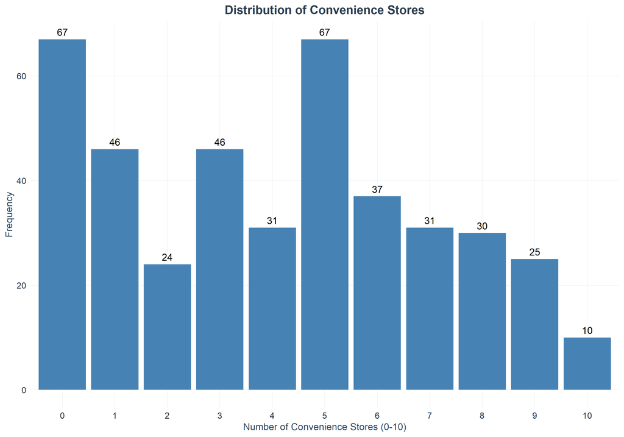

```r
# Order the categories
housing_clean$NumConvenStores <- factor(housing_clean$NumConvenStores,
                              levels = sort(unique(housing_clean$NumConvenStores)))

ggplot(housing_clean, aes(x = NumConvenStores)) +
  geom_bar(fill = "steelblue") +
  geom_text(stat = 'count', aes(label = after_stat(count)),
            vjust = -0.5, size = 4) +
  labs(title = "Distribution of Convenience Stores",
       x = "Number of Convenience Stores (0-10)",
       y = "Frequency") +
  #theme_minimal() +
  #theme(legend.position = "none",
  #      plot.title = element_text(hjust = 0.5, face = "bold")) +
  my.theme()
```

The above bar chart does not imply serious distributional issue. The relationship between number of convenience stores and the house unit price will be assess later.

- **Numerical Variables**

House Age, `HouseAge`, A and Distance to MRT, `Distance2MRT`, are the only two feature variables. The next plot shows the distribution and the potential mutual relationship.

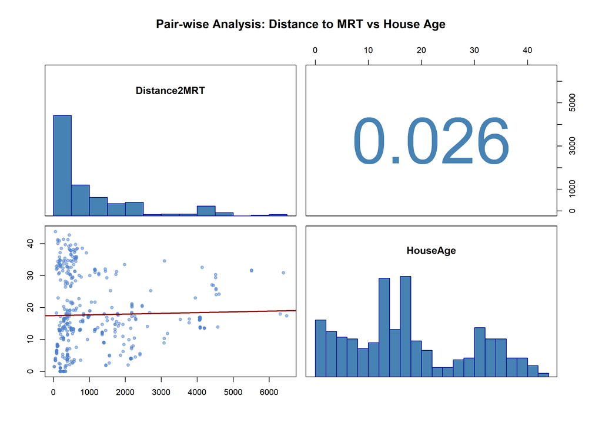

```r
# Base R approach with custom panels
# Define panel functions
panel.cor <- function(x, y, digits = 2, prefix = "", cex.cor, ...) {
  usr <- par("usr")
  on.exit(par(usr))
  par(usr = c(0, 1, 0, 1))
  r <- cor(x, y, use = "complete.obs")
  txt <- format(c(r, 0.123456789), digits = digits)[1]
  txt <- paste(prefix, txt, sep = "")
  if(missing(cex.cor)) cex.cor <- 0.8/strwidth(txt)
  text(0.5, 0.5, txt, cex = cex.cor * 0.8, col = "steelblue", font = 1.1)
}

panel.hist <- function(x, ...) {
  usr <- par("usr")
  on.exit(par(usr))
  par(usr = c(usr[1:2], 0, 1.5))
  h <- hist(x, plot = FALSE, breaks = 20)
  breaks <- h$breaks
  nB <- length(breaks)
  y <- h$counts
  y <- y/max(y)
  rect(breaks[-nB], 0, breaks[-1], y, col = "steelblue", border = "darkblue")
}

panel.scatter <- function(x, y, ...) {
  points(x, y, pch = 19, col = rgb(0.3, 0.5, 0.8, alpha = 0.5), cex = 0.8)
  abline(lm(y ~ x), col = "darkred", lwd = 2)
}

# Create the pairs plot
pairs(housing_clean[, c("Distance2MRT", "HouseAge")],
      lower.panel = panel.scatter,
      upper.panel = panel.cor,
      diag.panel = panel.hist,
      main = "Pair-wise Analysis: Distance to MRT vs House Age",
      cex.labels = 1.2,
      font.labels = 2)
```

The two continuous variables follow multi-modal distributions. While not a strict requirement, discretizing them facilitates interpretation of the regression model—a particularly useful feature when the model is applied to association analysis for real estate marketing. We will discretize these two in the subsequent feature engineering section.

A further pattern evident in the pair-wise plot above is the lack of correlation between the two variables ($r=0.026$), satisfying the theoretical assumption required of the feature variables.

- **Extract Geo-spatial Information**

We now investigate potential geographic patterns within the data, with the objective of defining a new feature that captures these patterns. A visual approach utilizing a mapper is adopted to identify possible clustering information. More advanced model-based clustering methods are not employed in this project.

```r
# Load required libraries
library(leaflet)
library(dplyr)

# Create leaflet map
leaflet(housing_clean) %>%
  addTiles() %>%  # Add default OpenStreetMap tiles
  addCircleMarkers(
    lng = ~Longitude,
    lat = ~Latitude,
    radius = 2,
    color = "purple",
    fillOpacity = 0.5,
     popup = ~paste(
      "<b>🏠 Property Details</b><br>",
      "━━━━━━━━━━━━━━━━━━━<br>",
      "📅 Transaction Year:", TransactionYear, "<br>",
      "🏚️ House Age:", HouseAge, "years<br>",
      "🚇 Distance to MRT:", round(Distance2MRT, 1), "m<br>",
      "🏪 Convenience Stores:", NumConvenStores, "<br>",
      "💰 Price per Unit Area:", PriceUnitArea, "<br>",
      "📍 Coordinates:", round(Latitude, 4), ",", round(Longitude, 4)
    ),
    label = ~paste(
      "Unit Price:", PriceUnitArea,
      " | Sold Year:", TransactionYear,
      " | Dist to MRT:", round(Distance2MRT, 0), "m",
      " | Numer of Stores",NumConvenStores
    )
  )
```

[interactive chart not shown]

The map exhibits a distinct geo-clustering pattern. We will utilize this pattern to define a categorical variable capable of capturing heterogeneity in the data. The scatter plot of longitude and latitude presented below facilitates visual identification of the clusters.

[interactive chart not shown]

Based on the above map, we divide the property locations into downtown and suburban using longitude = 121.529 and latitude = 24.96.

# 4 Feature Engineering

We will perform feature engineering tasks suggested in the previous visual exploratory data analysis. The relationship between the engineered features and house unit price for descriptive storytelling.

## 4.1 Descretizing Continuous Features

The above pairwise scatter plot will be used to suggest partition of the continuous features.

The distance variable is partitioned into the following intervals: 0, 500, 1000, 1500, 2000, and 2500+. This classification avoids potential problems associated with sparse categories.

- **Geo-cluster Extraction**

Using `longitude` and `latitude`, we define a grouping variable named `location` according to the following rule: `location is assigned "downtown"` when `longitude > 121.529` and `latitude > 24.96`; otherwise, `location` is assigned “suburban”

```r
# Feature engineering tasks
# discretizing distance to MRT
housing_clean$DistMRT.cat = cut(housing_clean$Distance2MRT,
     breaks = c(0, 500, 1000, 1500, 2000, 2500, Inf),
     labels = c("0-0.5K", "0.5K-1K", "1K-1.5K", "1.5K-2K", "2K-2.5K", "2.5K+"))

# discretizing house age
housing_clean$HouseAge.cat = cut(housing_clean$HouseAge,
     breaks = c(0, 10, 25, Inf),
     labels = c("0-10yr", "10yr-25yr", "25yr+"))

# Geo clustering
housing_clean$location <- ifelse(housing_clean$Longitude > 121.529 & housing_clean$Latitude > 24.96,
                      "downtown",
                      "suburban")
# Analytic data
var.name <- c("PriceUnitArea", "transaction_year", "NumStores_cat", "DistMRT.cat", "HouseAge.cat", "location")
FinalAnalyticData <- housing_clean[ , var.name]
```

## 4.2 Relationship Between Features and the House Price

After conducting visual exploratory data analysis, we now examine whether the predictor variables are associated with house unit prices. Given that this is solely a descriptive exploration, simple group boxplots are selected to evaluate this relationship.

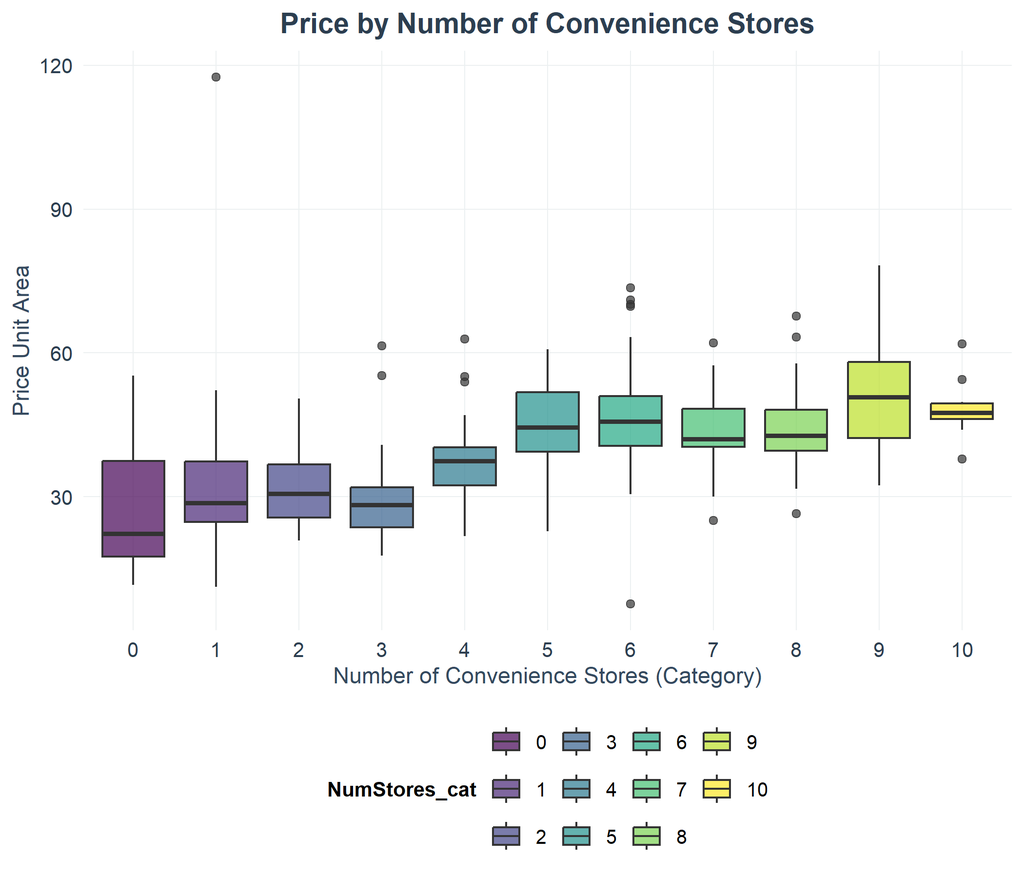

```r
# Load required libraries
#library(ggplot2)
#library(dplyr)
#library(tidyr)

# Read the data
df <- FinalAnalyticData

# Convert categorical variables to factors with proper levels
df$transaction_year <- as.factor(df$transaction_year)
df$NumStores_cat <- factor(df$NumStores_cat,
                           levels = c("0", "1", "2", "3", "4", "5", "6", "7", "8", "9", "10"),
                           ordered = TRUE)
df$DistMRT.cat <- factor(df$DistMRT.cat,
                         levels = c("0-0.5K", "0.5K-1K", "1K-1.5K", "1.5K-2K", "2K-2.5K", "2.5K+"),
                         ordered = TRUE)
df$HouseAge.cat <- factor(df$HouseAge.cat,
                          levels = c("0-10yr", "10yr-25yr", "25yr+"),
                          ordered = TRUE)
df$location <- as.factor(df$location)


#print(p1)

# 2. Relationship with NumStores_cat
p2 <- ggplot(df, aes(x = NumStores_cat, y = PriceUnitArea, fill = NumStores_cat)) +
  geom_boxplot(alpha = 0.7) +
  #geom_jitter(width = 0.2, alpha = 0.3, size = 0.8) +
  #stat_summary(fun = mean, geom = "point", shape = 18, size = 3, color = "red") +
  labs(title = "Price by Number of Convenience Stores",
       x = "Number of Convenience Stores (Category)",
       y = "Price Unit Area") +
  theme_minimal() +
  theme(legend.position = "none",
        axis.text.x = element_text(angle = 45, hjust = 1)) +
  scale_fill_viridis_d() +
  my.theme()
p2
```

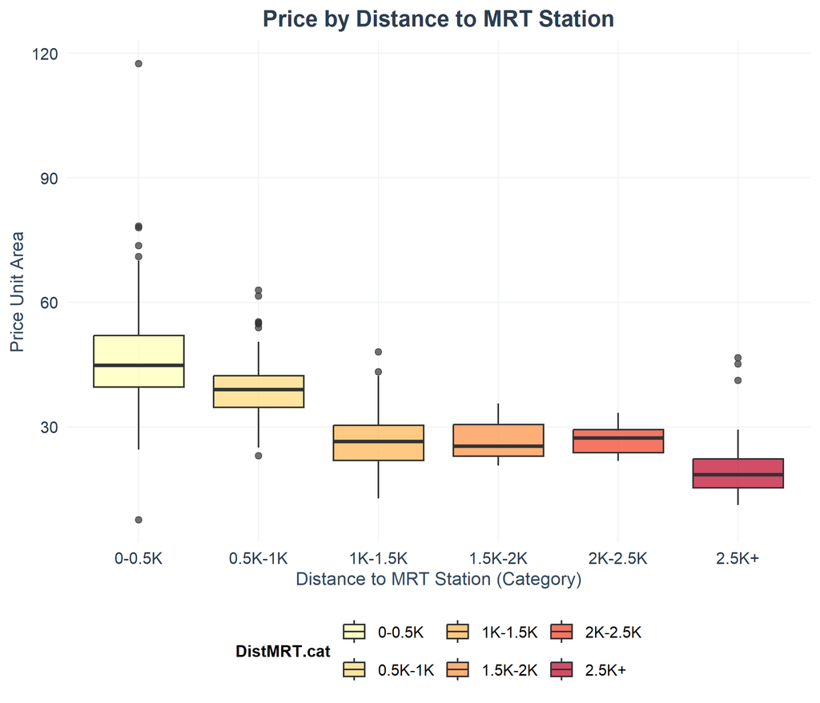

```r
# 3. Relationship with DistMRT.cat
p3 <- ggplot(df, aes(x = DistMRT.cat, y = PriceUnitArea, fill = DistMRT.cat)) +
  geom_boxplot(alpha = 0.7) +
  #geom_jitter(width = 0.2, alpha = 0.3, size = 0.8) +
  #stat_summary(fun = mean, geom = "point", shape = 18, size = 3, color = "red") +
  labs(title = "Price by Distance to MRT Station",
       x = "Distance to MRT Station (Category)",
       y = "Price Unit Area") +
  theme_minimal() +
  theme(legend.position = "none",
        axis.text.x = element_text(angle = 45, hjust = 1)) +
  scale_fill_brewer(palette = "YlOrRd") +
  my.theme()
p3
```

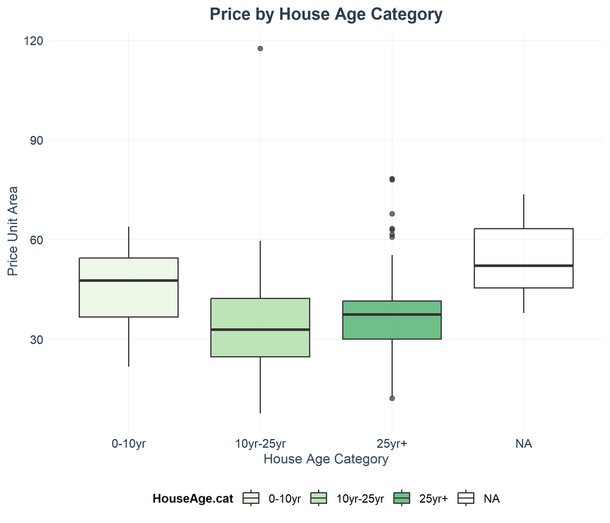

```r
# 4. Relationship with HouseAge.cat
p4 <- ggplot(df, aes(x = HouseAge.cat, y = PriceUnitArea, fill = HouseAge.cat)) +
  geom_boxplot(alpha = 0.7) +
  #geom_jitter(width = 0.2, alpha = 0.3, size = 0.8) +
  #stat_summary(fun = mean, geom = "point", shape = 18, size = 3, color = "red") +
  labs(title = "Price by House Age Category",
       x = "House Age Category",
       y = "Price Unit Area") +
  theme_minimal() +
  theme(legend.position = "none") +
  scale_fill_brewer(palette = "Greens") +
  my.theme()

p4
```

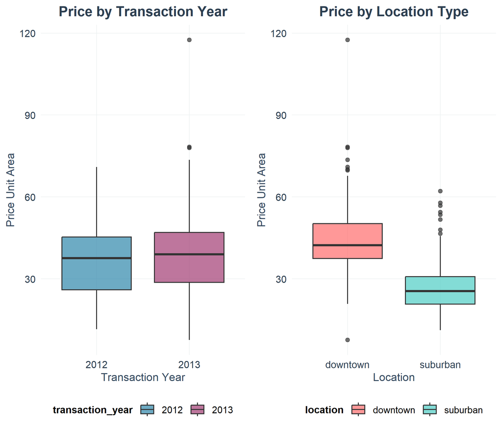

```r
# 1. Relationship with transaction_year
p1 <- ggplot(df, aes(x = transaction_year, y = PriceUnitArea, fill = transaction_year)) +
  geom_boxplot(alpha = 0.7) +
  #geom_jitter(width = 0.2, alpha = 0.3, size = 1) +
  #stat_summary(fun = mean, geom = "point", shape = 18, size = 3, color = "red") +
  labs(title = "Price by Transaction Year",
       x = "Transaction Year",
       y = "Price Unit Area") +
  theme_minimal() +
  theme(legend.position = "none") +
  scale_fill_manual(values = c("#2E86AB", "#A23B72")) +
  my.theme()


# 5. Relationship with location
p5 <- ggplot(df, aes(x = location, y = PriceUnitArea, fill = location)) +
  geom_boxplot(alpha = 0.7) +
  #geom_jitter(width = 0.2, alpha = 0.3, size = 0.8) +
  #stat_summary(fun = mean, geom = "point", shape = 18, size = 3, color = "red") +
  labs(title = "Price by Location Type",
       x = "Location",
       y = "Price Unit Area") +
  theme_minimal() +
  theme(legend.position = "none") +
  scale_fill_manual(values = c("#FF6B6B", "#4ECDC4")) +
  my.theme()

# Arrange multiple plots on a grid (requires gridExtra package)
if(require(gridExtra)) {
  grid.arrange(p1, p5, ncol = 2, nrow = 1)
}
```

# 5 Factors Influencing House Prices - Regression Analysis

This section is dedicated to the regression analysis of housing prices. The primary goal is to identify predictor variables that are both practically important and statistically significant in influencing house prices.

We follow the general regression workflow by first identifying the practically important variables to be included in the model regardless of their statistical significance, thereby formulating the simplest model. Since the dataset contains only five predictor variables, we define the full model to include all five. The final optimal candidate model will be determined using automatic variable selection procedures.

To identify the final model, we will perform standard model diagnostics and apply suitable remedies if necessary.

## 5.1 Candidate Models

The following two base models are used to search the potential optimal candidate model:

1. **Small model** contains only `location`:

$$\text{PriceUnitArea} = \alpha_0 + \alpha_1 \times \text{location}$$

```r
# Required libraries
# library(tidyverse)
# library(ggplot2)
# library(car)
# library(MASS)
# library(leaps)
# library(ggfortify)
# library(pander)

# Read the data
data <- FinalAnalyticData

# Check data structure
#str(data)

# Convert categorical variables to factors
data$transaction_year <- as.factor(data$transaction_year)
data$NumStores_cat <- as.factor(data$NumStores_cat)
data$DistMRT.cat <- as.factor(data$DistMRT.cat)
data$HouseAge.cat <- as.factor(data$HouseAge.cat)
data$location <- as.factor(data$location)

# Remove rows with NA in HouseAge.cat (rows 17, 86, 91, 104, 106, 124, 147, 165, 167, 212, 259, 279, 346, 358, 374, 380, 387)
data_clean <- data[!is.na(data$HouseAge.cat), ]

# (1) Smallest model: only location
model_small <- lm(PriceUnitArea ~ location, data = data_clean)
pander(round(summary(model_small)$coef,3))
```

|  | Estimate | Std. Error | t value | Pr(>\|t\|) |
| --- | --- | --- | --- | --- |
| **(Intercept)** | 43.5 | 0.669 | 65.05 | 0 |
| **locationsuburban** | -16.67 | 1.095 | -15.22 | 0 |

2. **full mode** contains all predictor variables

$$\text{PriceUnitArea} = \beta_0 + \beta_1 \times \text{location} +
\beta_2\times\text{transaction_year} + \cdots + \beta_5\times
\text{HouseAge.cat}$$

```r
# (2) Full model with all predictors
model_full <- lm(PriceUnitArea ~ transaction_year + NumStores_cat + DistMRT.cat +
                   HouseAge.cat + location, data = data_clean)
pander(round(summary(model_full)$coef,3))
```

|  | Estimate | Std. Error | t value | Pr(>\|t\|) |
| --- | --- | --- | --- | --- |
| **(Intercept)** | 44.3 | 2.24 | 19.78 | 0 |
| **transaction_year2013** | 2.939 | 0.928 | 3.168 | 0.002 |
| **NumStores_cat1** | 2.674 | 1.788 | 1.495 | 0.136 |
| **NumStores_cat10** | 8.293 | 3.265 | 2.54 | 0.011 |
| **NumStores_cat2** | 5.905 | 2.593 | 2.277 | 0.023 |
| **NumStores_cat3** | 4.23 | 2.119 | 1.996 | 0.047 |
| **NumStores_cat4** | 5.47 | 2.164 | 2.527 | 0.012 |
| **NumStores_cat5** | 4.564 | 2.051 | 2.225 | 0.027 |
| **NumStores_cat6** | 2.839 | 2.387 | 1.189 | 0.235 |
| **NumStores_cat7** | 4.555 | 2.364 | 1.927 | 0.055 |
| **NumStores_cat8** | 7.291 | 2.379 | 3.065 | 0.002 |
| **NumStores_cat9** | 9.253 | 2.628 | 3.52 | 0 |
| **DistMRT.cat0.5K-1K** | -3.797 | 1.531 | -2.481 | 0.014 |
| **DistMRT.cat1K-1.5K** | -13.03 | 2.165 | -6.017 | 0 |
| **DistMRT.cat1.5K-2K** | -16.51 | 2.866 | -5.761 | 0 |
| **DistMRT.cat2K-2.5K** | -17.25 | 2.85 | -6.053 | 0 |
| **DistMRT.cat2.5K+** | -16.45 | 2.503 | -6.572 | 0 |
| **HouseAge.cat10yr-25yr** | -7.369 | 1.156 | -6.376 | 0 |
| **HouseAge.cat25yr+** | -9.505 | 1.274 | -7.462 | 0 |
| **locationsuburban** | -2.554 | 1.697 | -1.505 | 0.133 |

3. **auto selected model**

```r
# (3) Automatic variable selection algorithms

# Forward selection
model_forward <- step(lm(PriceUnitArea ~ 1, data = data_clean),
                      scope = formula(model_full),
                      direction = "forward",
                      trace = FALSE)
pander(round(summary(model_forward)$coef,3))
```

|  | Estimate | Std. Error | t value | Pr(>\|t\|) |
| --- | --- | --- | --- | --- |
| **(Intercept)** | 44.3 | 2.24 | 19.78 | 0 |
| **DistMRT.cat0.5K-1K** | -3.797 | 1.531 | -2.481 | 0.014 |
| **DistMRT.cat1K-1.5K** | -13.03 | 2.165 | -6.017 | 0 |
| **DistMRT.cat1.5K-2K** | -16.51 | 2.866 | -5.761 | 0 |
| **DistMRT.cat2K-2.5K** | -17.25 | 2.85 | -6.053 | 0 |
| **DistMRT.cat2.5K+** | -16.45 | 2.503 | -6.572 | 0 |
| **HouseAge.cat10yr-25yr** | -7.369 | 1.156 | -6.376 | 0 |
| **HouseAge.cat25yr+** | -9.505 | 1.274 | -7.462 | 0 |
| **transaction_year2013** | 2.939 | 0.928 | 3.168 | 0.002 |
| **NumStores_cat1** | 2.674 | 1.788 | 1.495 | 0.136 |
| **NumStores_cat10** | 8.293 | 3.265 | 2.54 | 0.011 |
| **NumStores_cat2** | 5.905 | 2.593 | 2.277 | 0.023 |
| **NumStores_cat3** | 4.23 | 2.119 | 1.996 | 0.047 |
| **NumStores_cat4** | 5.47 | 2.164 | 2.527 | 0.012 |
| **NumStores_cat5** | 4.564 | 2.051 | 2.225 | 0.027 |
| **NumStores_cat6** | 2.839 | 2.387 | 1.189 | 0.235 |
| **NumStores_cat7** | 4.555 | 2.364 | 1.927 | 0.055 |
| **NumStores_cat8** | 7.291 | 2.379 | 3.065 | 0.002 |
| **NumStores_cat9** | 9.253 | 2.628 | 3.52 | 0 |
| **locationsuburban** | -2.554 | 1.697 | -1.505 | 0.133 |

## 5.2 Residual Dianostic Analysis

The residual-based plots—namely, the residual plot, Q-Q plot, studentized residual plot, and leverage plot—are summarized as follows.

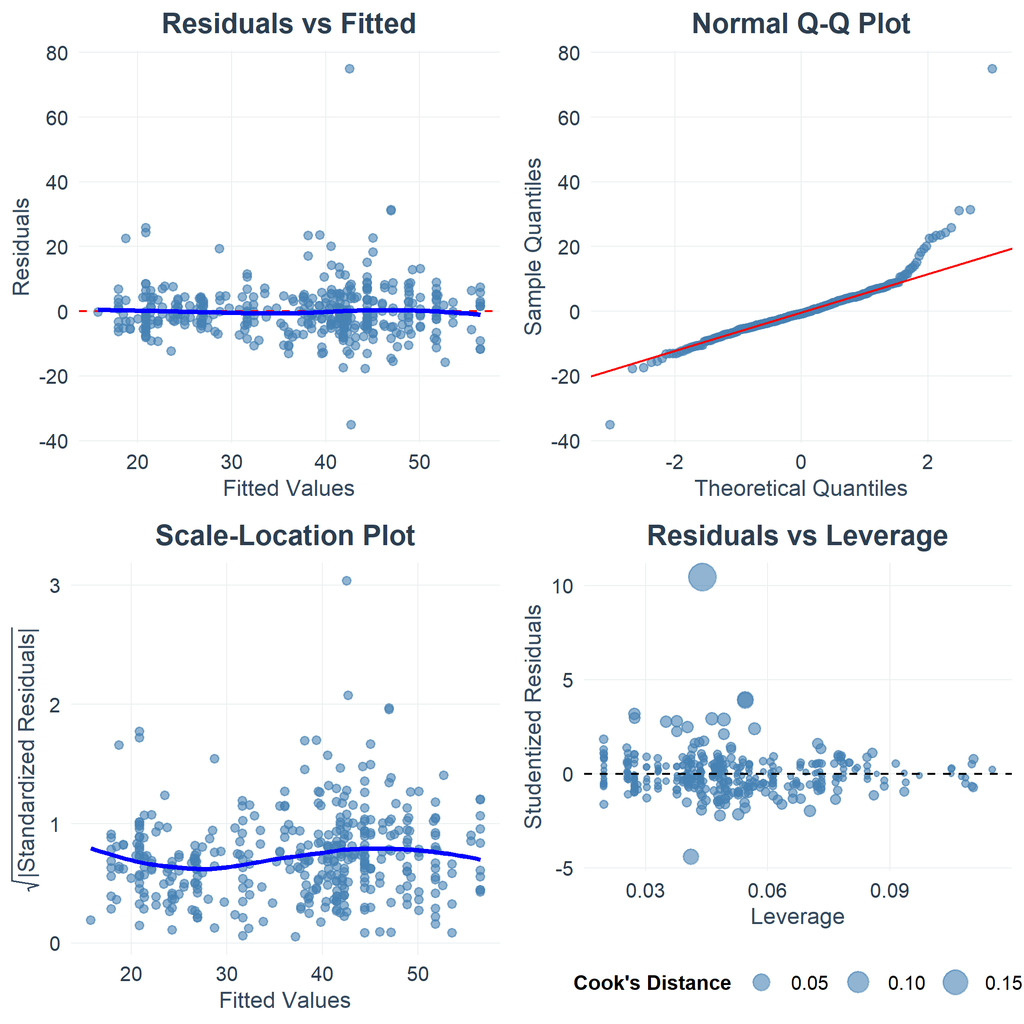

```r
# Diagnostic plots for the model_forward model
# Residuals vs Fitted using ggplot
residual_data <- data.frame(
  Fitted = fitted(model_forward),
  Residuals = residuals(model_forward),
  Standardized = rstandard(model_forward),
  Studentized = rstudent(model_forward)
)

# Residuals vs Fitted plot
p1 <- ggplot(residual_data, aes(x = Fitted, y = Residuals)) +
  geom_point(alpha = 0.6, color = "steelblue") +
  geom_hline(yintercept = 0, linetype = "dashed", color = "red") +
  geom_smooth(se = FALSE, method = "loess", color = "blue") +
  labs(title = "Residuals vs Fitted",
       x = "Fitted Values",
       y = "Residuals") +
  my.theme()

# Q-Q plot
p2 <- ggplot(residual_data, aes(sample = Residuals)) +
  stat_qq(alpha = 0.6, color = "steelblue") +
  stat_qq_line(color = "red") +
  labs(title = "Normal Q-Q Plot",
       x = "Theoretical Quantiles",
       y = "Sample Quantiles") +
  my.theme()

# Scale-Location plot
p3 <- ggplot(residual_data, aes(x = Fitted, y = sqrt(abs(Standardized)))) +
  geom_point(alpha = 0.6, color = "steelblue") +
  geom_smooth(se = FALSE, method = "loess", color = "blue") +
  labs(title = "Scale-Location Plot",
       x = "Fitted Values",
       y = expression(sqrt("|Standardized Residuals|"))) +
  my.theme()

# Residuals vs Leverage
# Calculate leverage and Cook's distance
leverage <- hatvalues(model_forward)
cooksd <- cooks.distance(model_forward)

residual_data$Leverage <- leverage
residual_data$CookSD <- cooksd

p4 <- ggplot(residual_data, aes(x = Leverage, y = Studentized)) +
  geom_point(aes(size = CookSD), alpha = 0.6, color = "steelblue") +
  geom_hline(yintercept = 0, linetype = "dashed") +
  labs(title = "Residuals vs Leverage",
       x = "Leverage",
       y = "Studentized Residuals") +
  theme_minimal() +
  scale_size_continuous("Cook's Distance") +
  my.theme()

# Arrange plots
library(gridExtra)
grid.arrange(p1, p2, p3, p4, ncol = 2, nrow = 2)
```

A clear violation of the normality assumption in the regression model is the skewness of the residuals. This indicates that a transformation of the response variable, `PriceUnitArea`, warrants investigation. Consequently, we proceed with the generic Box-Cox power transformation.

## 5.3 Box-Cox Transformation

We perform Box-Cox transformation based on the candidate model: `model_forward`.

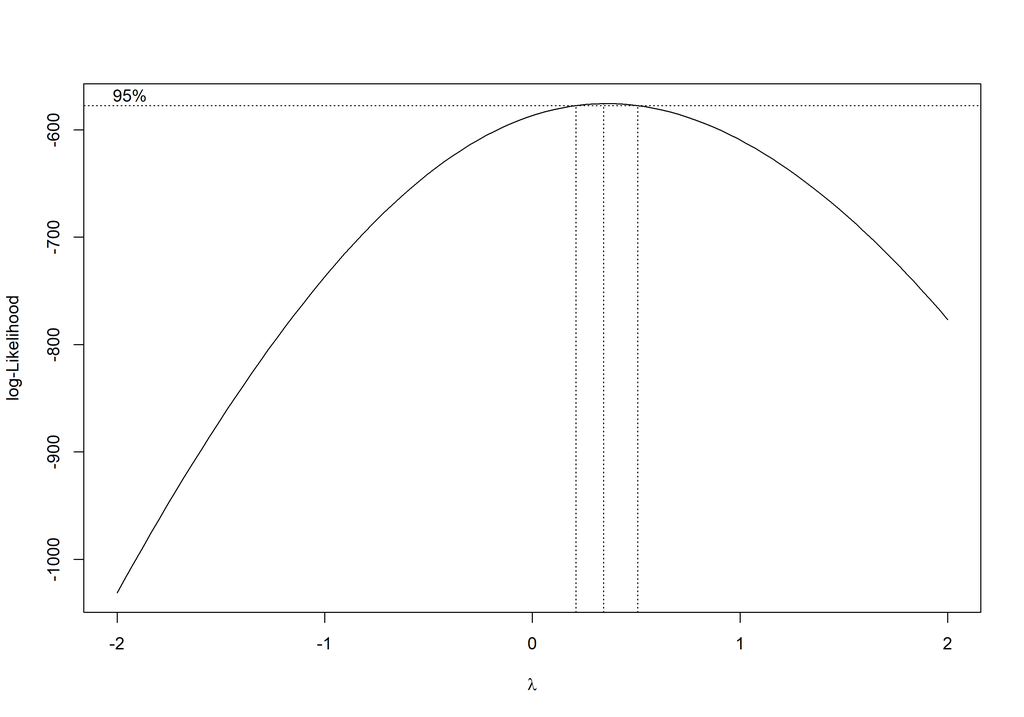

```r
# (5) Box-Cox transformation

# Perform Box-Cox transformation
boxcox_result <- boxcox(model_forward, lambda = seq(-2, 2, length = 100))
```

```r
# Find optimal lambda
lambda_opt <- boxcox_result$x[which.max(boxcox_result$y)]
cat("Optimal lambda for Box-Cox transformation:", lambda_opt, "\n")
```

```
Optimal lambda for Box-Cox transformation: 0.3434
```

Some of the key goodness-of-fit metrics for the transformed model are summarized as follows.

```r
# Create transformed response variable
if(lambda_opt != 0) {
  data_clean$PriceUnitArea_trans <- (data_clean$PriceUnitArea^lambda_opt - 1)/lambda_opt
} else {
  data_clean$PriceUnitArea_trans <- log(data_clean$PriceUnitArea)
}

# Fit model with transformed response
model_transformed <- update(model_forward, PriceUnitArea_trans ~ .)

# Compare original and transformed models
cat("\n=== Model Comparison ===\n \n",
"Original model R-squared:", summary(model_forward)$r.squared, "\n\n",
"Transformed model R-squared:", summary(model_transformed)$r.squared, "\n\n",
"Original model AIC:", AIC(model_forward), "\n\n",
"Transformed model AIC:", AIC(model_transformed), "\n")
```

```
=== Model Comparison ===

 Original model R-squared: 0.6263

 Transformed model R-squared: 0.6769

 Original model AIC: 2830

 Transformed model AIC: 911.9
```

The above $R^2$ indicates a marginal improvement.

**Caution**: Because AIC is calculated from the log-likelihood, and the log-likelihood depends on the scale of the response variable, the AIC scores from the original model and the transformed model are not directly comparable!

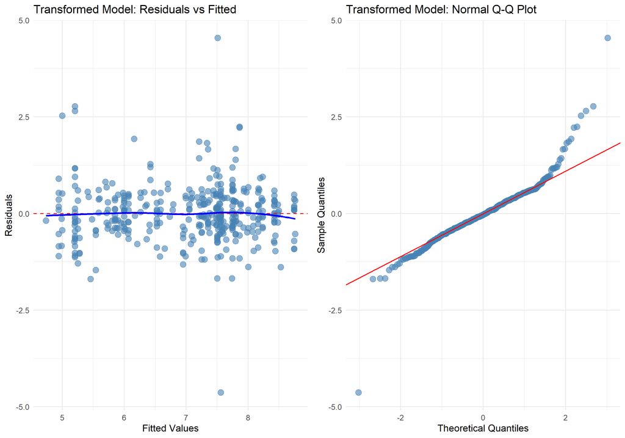

```r
# Diagnostic plots for transformed model
residual_data_trans <- data.frame(
  Fitted = fitted(model_transformed),
  Residuals = residuals(model_transformed),
  Standardized = rstandard(model_transformed)
)

p1_trans <- ggplot(residual_data_trans, aes(x = Fitted, y = Residuals)) +
  geom_point(alpha = 0.6, color = "steelblue", size = 3) +
  geom_hline(yintercept = 0, linetype = "dashed", color = "red") +
  geom_smooth(se = FALSE, method = "loess", color = "blue") +
  labs(title = "Transformed Model: Residuals vs Fitted",
       x = "Fitted Values",
       y = "Residuals") +
  theme_minimal()

p2_trans <- ggplot(residual_data_trans, aes(sample = Residuals)) +
  stat_qq(alpha = 0.6, color = "steelblue", size = 3) +
  stat_qq_line(color = "red") +
  labs(title = "Transformed Model: Normal Q-Q Plot",
       x = "Theoretical Quantiles",
       y = "Sample Quantiles") +
  theme_minimal()

grid.arrange(p1_trans, p2_trans, ncol = 2)
```

# 6 Summary of Optimal Model

A multiple linear regression model was estimated to predict house price per unit area (PriceUnitArea) based on location characteristics, building age, transaction year, and nearby amenities. The model explains a substantial portion of the variance in housing prices, with an adjusted R-squared of 0.607, meaning that approximately 60.7% of the variability in price per unit area is accounted for by the predictors. The overall model is highly significant ($F(19, 377) = 33.3$, $p < .001$).

**Key Predictors**:

- **Distance to MRT (DistMRT.cat)**: Compared to the baseline category ($<500m$), all longer distance categories are associated with significantly lower prices. The effect is progressive: properties 0.5–1 km from an MRT station are priced about 3.8 units lower, while those 1.5–2 km, 2–2.5 km, and beyond 2.5 km show reductions of roughly 16–17 units. This indicates a strong negative gradient of price with distance from transit.
- **House Age (HouseAge.cat)**: Relative to newer houses ($<10$ years), older houses command significantly lower prices. Houses aged 10–25 years are discounted by approximately 7.4 units, and those older than 25 years by about 9.5 units, holding all else constant.

Transaction Year: The coefficient for 2013 (vs. 2012) is positive and significant, with prices in 2013 being roughly 2.94 units higher, suggesting a modest year-over-year price increase.

- **Number of Convenience Stores (NumStores_cat)**: Compared to having zero stores, the presence of stores generally increases price, with effects becoming more pronounced at higher counts (e.g., 10 stores: +8.3 units, 9 stores: +9.3 units). However, not all categories are statistically significant (e.g., 1 store and 6 stores show no significant difference at $\alpha = 0.05$).
- **Location Type**: The suburban coefficient is negative but not statistically significant ($p = 0.133$), indicating that after accounting for other factors, location type does not have a clear independent effect.

Overall, the model confirms that proximity to MRT, newer building age, and a greater number of nearby convenience stores are associated with higher house prices per unit area. The residuals range from -35.1 to 74.9, with a median near zero, suggesting reasonable model fit though with some large positive outliers.